# Trabajo módulo n°3 Data Science

### **4.Clientes con algún prestamo para vivienda**

```r
hous_bar= table(dat$housing)
hous_bar
```

```
##
##      no unknown     yes
##   14900     796   17254
```

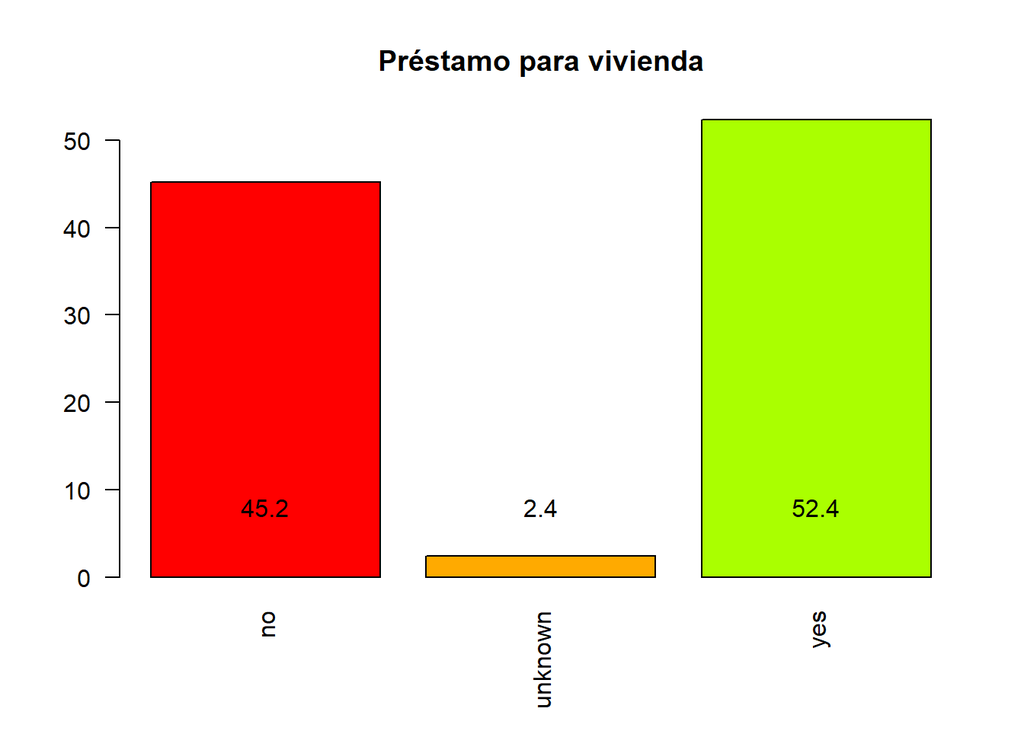

```r
porce =prop.table(hous_bar)*100
hous_barr =barplot(porce, las=2, main = "Préstamo para vivienda", col= rainbow(9))
text(hous_barr, c(8), round(porce,1))
```

Al consultar por si los clientes del banco poseen algún prestamo para vivienda, se observa que; 52,4% señala sí tener y un 45,2% señala no tener.

### **5.Clientes con algún préstamo personal**

```r
loan_bar= table(dat$loan)
loan_bar
```

```
##
##      no unknown     yes
##   27131     796    5023
```

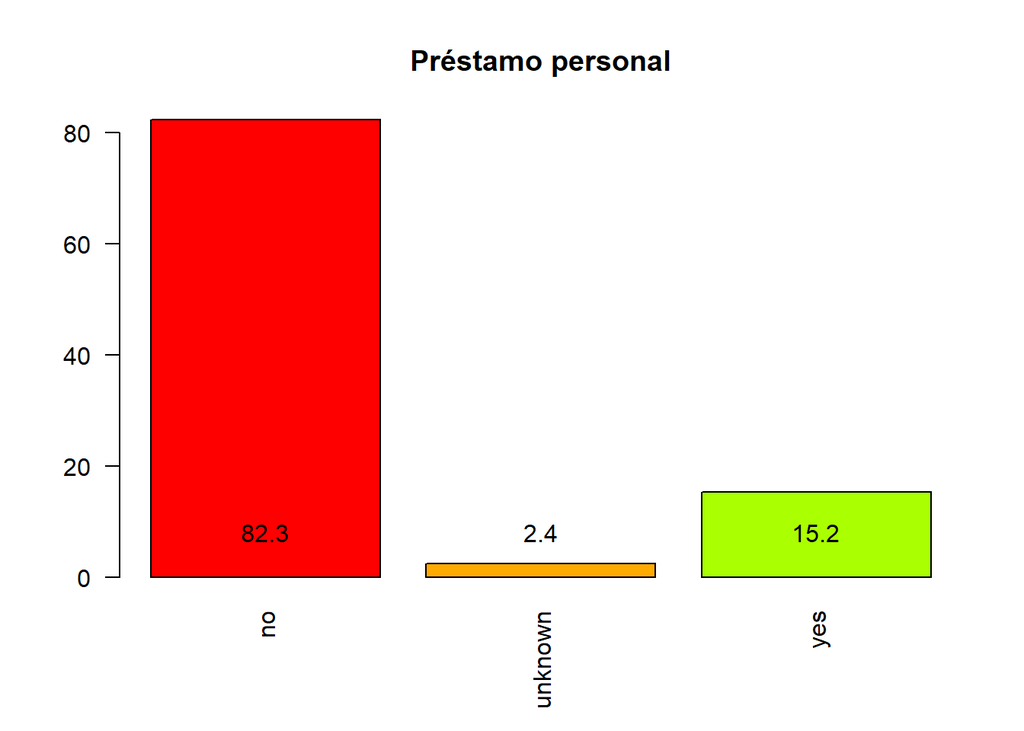

```r
porce =prop.table(loan_bar)*100
loan_barr =barplot(porce, las=2, main = "Préstamo personal", col= rainbow(9))
text(loan_barr, c(8), round(porce,1))
```

Al consultar por si los clientes del banco poseen algún prestamo personal, se observa que; 82,3% señala no tener y un 15,2% señala sí tener.

### **6.Cantidad de contactos durante la campaña (con histograma para ver tabla de frecuencia)**

```r
summary(dat$campaign)
```

```
##    Min. 1st Qu.  Median    Mean 3rd Qu.    Max.
##   1.000   1.000   2.000   2.561   3.000  56.000
```

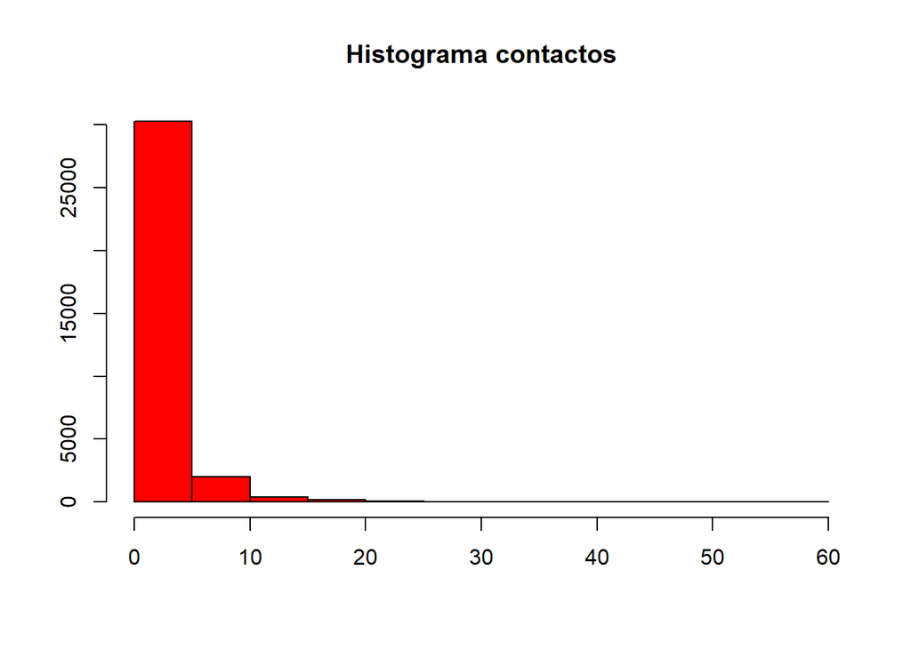

```r
Histcon= hist(dat$campaign, main="Histograma contactos", col="red", xlab="", ylab="")
```

```r
tabla = table.freq(Histcon)
tabla
```

```
##    Lower Upper Main Frequency Percentage    CF   CPF
## 1      0     5  2.5     30261       91.8 30261  91.8
## 2      5    10  7.5      2002        6.1 32263  97.9
## 3     10    15 12.5       405        1.2 32668  99.1
## 4     15    20 17.5       158        0.5 32826  99.6
## 5     20    25 22.5        65        0.2 32891  99.8
## 6     25    30 27.5        35        0.1 32926  99.9
## 7     30    35 32.5        17        0.1 32943 100.0
## 8     35    40 37.5         2        0.0 32945 100.0
## 9     40    45 42.5         4        0.0 32949 100.0
## 10    45    50 47.5         0        0.0 32949 100.0
## 11    50    55 52.5         0        0.0 32949 100.0
## 12    55    60 57.5         1        0.0 32950 100.0
```

Se observa que el 50% de los clientes fueron contactados durante la campaña entre 1 a 3 veces. La mediana es de 2 contactos y la media de 2.56.

### **7.Medio de contacto**

```r
contact_pie= table(dat$contact)
contact_pie
```

```
##
##  cellular telephone
##     20908     12042
```

```r
table(dat$contact)/32950
```

```
##
##  cellular telephone
## 0.6345372 0.3654628
```

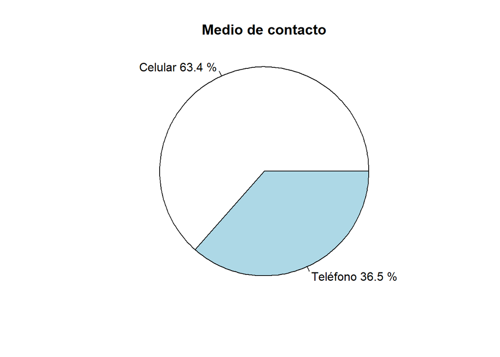

```r
labels = c("Celular", "Teléfono")
porcentajes = c(0.634*100, 0.365*100)
tags =paste(labels, porcentajes, "%", sep = " ")
pie(porcentajes, labels  =tags, main = "Medio de contacto", radius = 1)
```

Sobre el medio de contacto que se utilizó para realizar la campaña, un 63,4% fue contactado por celular y un 36,5% a través de teléfono fijo.

### **8.Mes del último contacto**

```r
summary(dat$month)
```

```
##   apr   aug   dec   jul   jun   mar   may   nov   oct   sep
##  2085  4948   143  5763  4247   436 11011  3266   587   464
```